# Decision Trees and Random Forests - Philippe Jacquet - 2026

The practicals can be done on various computing platforms. See the installation page for more information:

https://wiki.unil.ch/ci/books/high-performance-computing-hpc/page/course-software-for-decision-trees-random-forests

# Libraries

Let us load all the required libraries:

```python
from sklearn.datasets import load_iris
from sklearn.model_selection import train_test_split, GridSearchCV
from sklearn.preprocessing import LabelEncoder
from sklearn.metrics import confusion_matrix
from sklearn.ensemble import RandomForestClassifier
from sklearn.tree import DecisionTreeClassifier, export_graphviz
from sklearn import tree

import matplotlib.pyplot as plt
from matplotlib.colors import ListedColormap

import pandas as pd
from pandas.plotting import scatter_matrix

import graphviz
import seaborn as sns
import numpy as np
import random

import warnings
warnings.filterwarnings('ignore')
```

# Exploration analysis

We will first do some exploratory data analysis.

Let us have a look at the dataset:

```python
data_iris=load_iris()

names=[f_name.replace(" ", "_").strip("_(cm)") for f_name in data_iris.feature_names]

iris=pd.DataFrame(data_iris.data, columns=names)

iris["species"]=["setosa" for i in range(50)]+["versicolor" for i in range(50)]+["virginica" for i in range(50)]

iris.head(3)
```

|  | sepal_length | sepal_width | petal_length | petal_width | species |
| --- | --- | --- | --- | --- | --- |
| 0 | 5.1 | 3.5 | 1.4 | 0.2 | setosa |
| 1 | 4.9 | 3.0 | 1.4 | 0.2 | setosa |
| 2 | 4.7 | 3.2 | 1.3 | 0.2 | setosa |

```python
iris.shape
```

```
(150, 5)
```

```python
iris.describe()
```

|  | sepal_length | sepal_width | petal_length | petal_width |
| --- | --- | --- | --- | --- |
| count | 150.000000 | 150.000000 | 150.000000 | 150.000000 |
| mean | 5.843333 | 3.057333 | 3.758000 | 1.199333 |
| std | 0.828066 | 0.435866 | 1.765298 | 0.762238 |
| min | 4.300000 | 2.000000 | 1.000000 | 0.100000 |
| 25% | 5.100000 | 2.800000 | 1.600000 | 0.300000 |
| 50% | 5.800000 | 3.000000 | 4.350000 | 1.300000 |
| 75% | 6.400000 | 3.300000 | 5.100000 | 1.800000 |
| max | 7.900000 | 4.400000 | 6.900000 | 2.500000 |

```python
iris.groupby("species").size()
```

```
species
setosa        50
versicolor    50
virginica     50
dtype: int64
```

We see that there are four input features (Sepal Length, Sepal Width, Petal Length and Petal Width), expressed in centimeters, and one output feature (Species). We can also see that the Iris dataset is balanced with 50 species of each flower.

Let us now make pairwise scatterplots of each of the four input features versus any other feature:

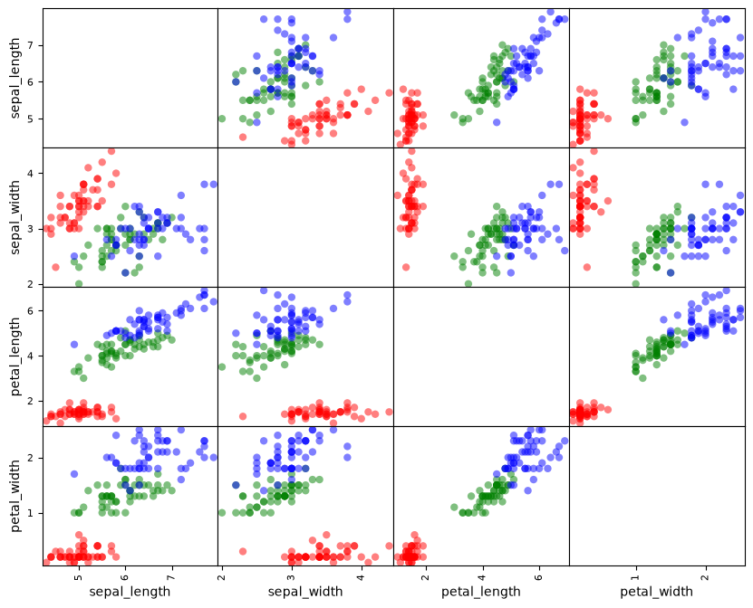

```python
colours=["red" for i in range(50)]+["green" for i in range(50)]+["blue" for i in range(50)]
scatter_matrix(iris,figsize=(10,8),marker="o",c=colours,diagonal=None)
plt.show()
```

Here and in all subsequent plots the colour labels are: red=setosa, green=versicolor, blue=virginica. We see that the knowledge of a single feature, Petal Width or Petal Length, already allows us to predict quite well in which species a given plant belongs to. To improve the quality of our classifier, let us use the two most informative features, Petal Width and Petal Length, and plot one versus the other:

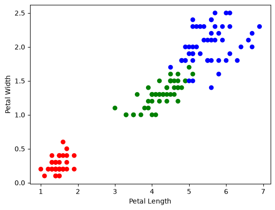

```python
plt.scatter(iris["petal_length"],iris["petal_width"],c=colours)
plt.xlabel("Petal Length")
plt.ylabel("Petal Width")
plt.show()
```

We see in the above plot that using only the Petal Length and Petal Width variables, one should be able to classify the plants by species. Anyway, we shall use the 4 measurements in the decision trees and random forests.

# Decision tree

We are now going to build a decision tree to predict the species a given Iris plant (represented by the four measurements Sepal Width, Sepal Length, Petal Length, Petal Width) belongs to. Try to go through all the steps and to understand what each step is doing.

Let us set the seeds to some values to make the whole analysis reproducible, and split the Iris dataset into a training set, a validation set and a test set:

```python
seed=65
np.random.seed(seed)
random.seed(seed)
random_state=70
```

```python
iris_training,iris_test,iris_trainingtarget,iris_testtarget=train_test_split(iris.loc[:,"sepal_length":"petal_width"],iris.loc[:,"species"],
                                                                             test_size=0.2,random_state=seed)
iris_training,iris_validation,iris_trainingtarget,iris_validationtarget=train_test_split(iris_training,iris_trainingtarget,
                                                                                         test_size=0.25,random_state=seed) # 0.25 x 0.8 = 0.2

encoder=LabelEncoder()
iris_trainingtarget_integers=encoder.fit_transform(iris_trainingtarget)
iris_validationtarget_integers=encoder.fit_transform(iris_validationtarget)
iris_testtarget_integers=encoder.fit_transform(iris_testtarget)
```

Make the decision tree model using the entropy as the impurity index, and (min_samples_split=10, min_samples_leaf=5, max_depth=2) as stopping rules:

```python
decision_tree=DecisionTreeClassifier(criterion="entropy",min_samples_split=10,min_samples_leaf=5,max_depth=2,random_state=random_state)
decision_tree=decision_tree.fit(iris_training,iris_trainingtarget_integers)
```

Here the random_state variable controls the internal random generator that is used by the decision tree algorithm (for example for selecting one of the best questions if there are several questions with the same largest information gain).

To show all the possible options, you may type help(DecisionTreeClassifier), or look at the sklearn documentation :

https://scikit-learn.org/stable/modules/generated/sklearn.tree.DecisionTreeClassifier.html

Comment: if you want to make a regression tree, you may use DecisionTreeRegressor (from sklearn.tree import DecisionTreeRegressor).

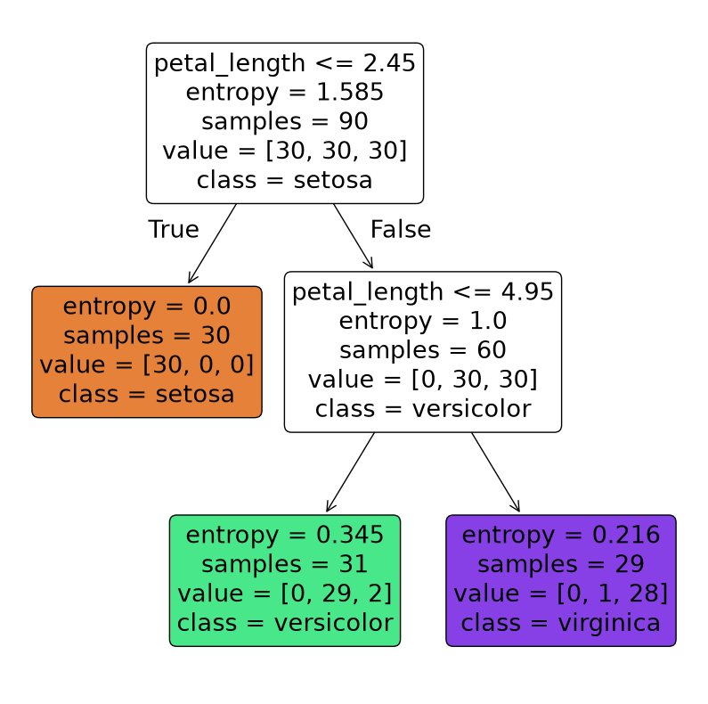

```python
plt.figure(figsize=(10,10))
tree.plot_tree(decision_tree,feature_names=list(iris_training),class_names=["setosa","versicolor","virginica"],
               filled=True,rounded=True)
plt.show()
```

The left-hand-side arrows correspond to "True" or "Yes" and the right-hand-side ones to "False" or "No". We see that the first two questions (or splits) of the decision tree use Petal Length. You may want to look again at the exploratory analysis that we have done before building the decision tree (the plot of Petal Width versus Petal Length). This may help you to understand better the iris tree structure.

Comment: Instead of using "tree.plot_tree" to plot the decision tree, you may use Graphviz:

1. Install Graphviz: https://graphviz.org/download/
2. Check that the command "dot" is available on your terminal:

$ dot -V

The output should be something like "dot - graphviz version 5.0.1".

3. Use the following commands:

dot_data=export_graphviz(decision_tree,out_file=None,feature_names=list(iris_training),class_names=["setosa","versicolor","virginica"], filled=True,rounded=True,special_characters=True)

graph=graphviz.Source(dot_data, format="pdf")

graph

On Curnagl you need to type: graph.view()

Predict the species for the training dataset:

```python
predictions_training=decision_tree.predict(iris_training)
confusion_matrix(iris_trainingtarget_integers,predictions_training)
```

```
array([[30,  0,  0],
       [ 0, 29,  1],
       [ 0,  2, 28]])
```

This confusion matrix shows that the decision tree has made 3 mistakes in 90 preditions. The corresponding training accuracy:

```python
scores=decision_tree.score(iris_training,iris_trainingtarget_integers)
print("Training accuracy rate:: %.2f%%"%(scores*100))
print("Training error rate: %.2f%%"%(100-scores*100))
```

```
Training accuracy rate:: 96.67%
Training error rate: 3.33%
```

Predict the species for the validation dataset:

```python
predictions_validation=decision_tree.predict(iris_validation)
confusion_matrix(iris_validationtarget_integers,predictions_validation)
```

```
array([[ 9,  0,  0],
       [ 0, 12,  0],
       [ 0,  1,  8]])
```

This confusion matrix shows that the decision tree has made 1 mistake in 30 predictions. The corresponding validation accuracy:

```python
scores=decision_tree.score(iris_validation,iris_validationtarget_integers)
print("Validation accuracy rate:: %.2f%%"%(scores*100))
print("Validation error rate: %.2f%%"%(100-scores*100))
```

```
Validation accuracy rate:: 96.67%
Validation error rate: 3.33%
```

Above we used (min_samples_split=10,min_samples_leaf=5,max_depth=2) as stopping rules. Let us now use the cost complexity pruning method instead to find the best tree:

```python
decision_tree=DecisionTreeClassifier(criterion="entropy",random_state=random_state)
decision_tree=decision_tree.fit(iris_training,iris_trainingtarget_integers)
```

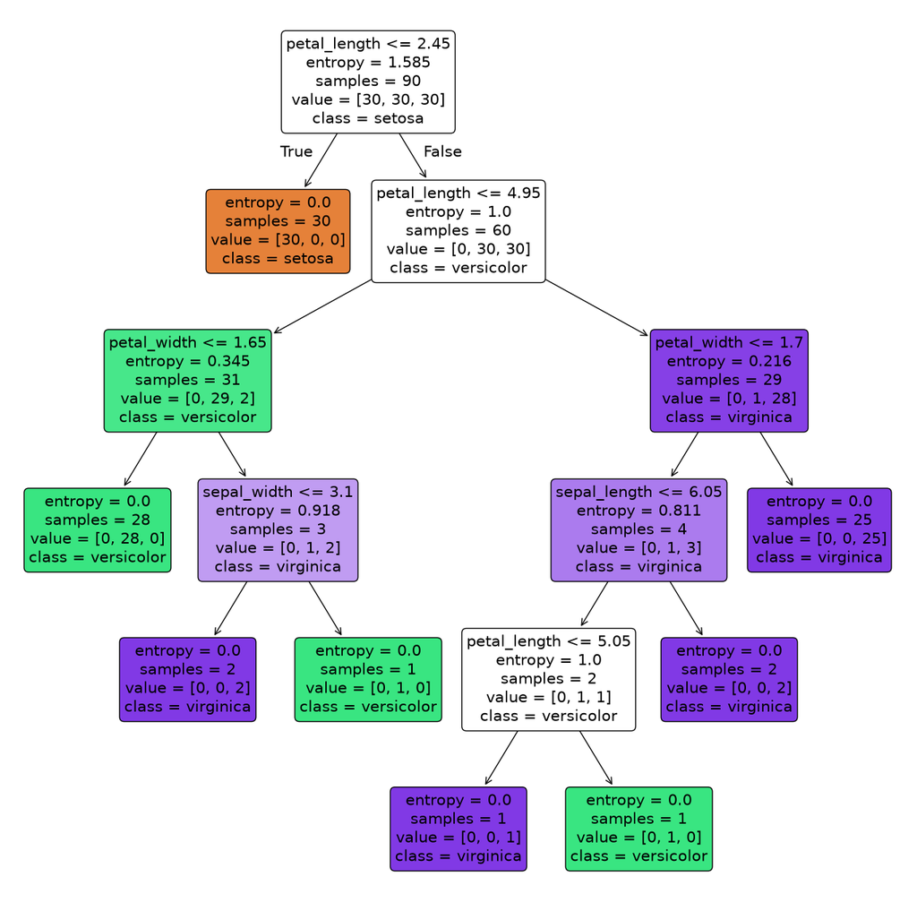

```python
plt.figure(figsize=(16,16))
tree.plot_tree(decision_tree,feature_names=list(iris_training),class_names=["setosa","versicolor","virginica"],
               filled=True,rounded=True)
plt.show()
```

This is the biggest tree possible. We now need to prune this tree up to the smallest validation error (or highest validation accuracy). Let us first find the values of the cost complexity pruning parameter alpha (ccp_alpha):

```python
path=decision_tree.cost_complexity_pruning_path(iris_training,iris_trainingtarget_integers)
ccp_alphas=path.ccp_alphas
```

We remove the last element in ccp_alphas because it corresponds to the trivial tree with only one node:

```python
ccp_alphas=ccp_alphas[:-1]
```

Let us look at the alpha values:

```python
ccp_alphas
```

```
array([0.        , 0.0180284 , 0.03060986, 0.03367109, 0.08826388,
       0.47806502])
```

We loop over the subtrees associated to these alpha values:

```python
subtrees=[]
for ccp_alpha in ccp_alphas:
    subtree=DecisionTreeClassifier(criterion="entropy",ccp_alpha=ccp_alpha,random_state=random_state)
    subtree.fit(iris_training,iris_trainingtarget_integers)
    subtrees.append(subtree)
```

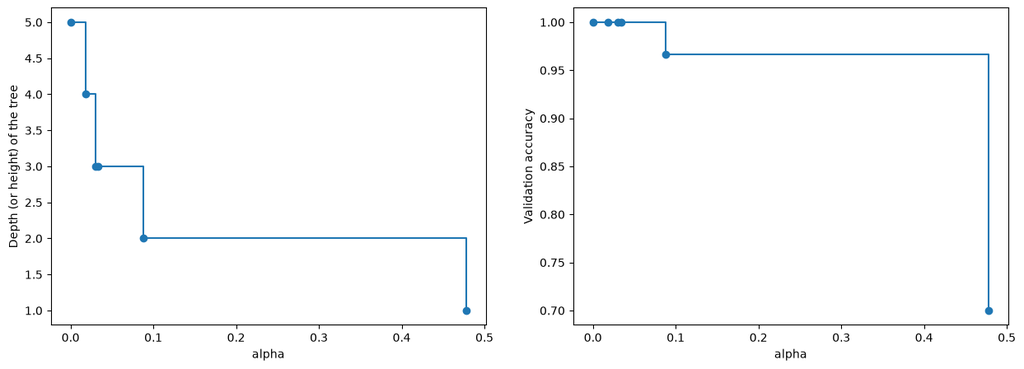

```python
depths=[subtree.tree_.max_depth for subtree in subtrees]
validation_accuracies = [subtree.score(iris_validation,iris_validationtarget_integers) for subtree in subtrees]

fig,ax=plt.subplots(1,2,figsize=(15, 5))
ax[0].plot(ccp_alphas,depths,marker='o',drawstyle="steps-post")
ax[0].set_xlabel("alpha")
ax[0].set_ylabel("Depth (or height) of the tree")

ax[1].set_xlabel("alpha")
ax[1].set_ylabel("Validation accuracy")
ax[1].plot(ccp_alphas,validation_accuracies,marker='o',drawstyle="steps-post")
plt.show()
```

We see that the largest validation accuracy is 1 and that it is reached for alpha values between 0 and 0.1. Considering the smallest tree with a value of alpha in this interval, we set alpha=0.07 (which corresponds to a tree of depth 3):

```python
pruned_tree=DecisionTreeClassifier(criterion="entropy",ccp_alpha=0.07,random_state=random_state)
pruned_tree=pruned_tree.fit(iris_training,iris_trainingtarget_integers)
```

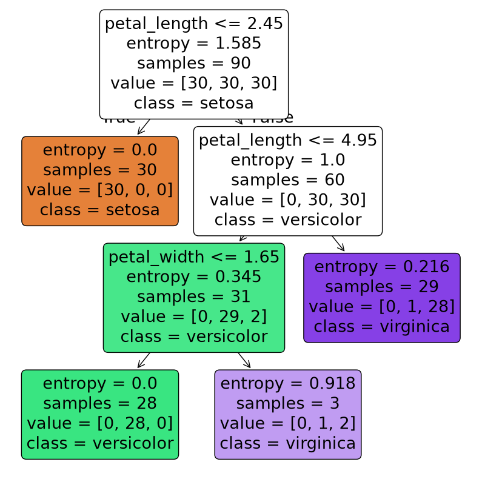

```python
plt.figure(figsize=(10,10))
tree.plot_tree(pruned_tree,feature_names=list(iris_training),class_names=["setosa","versicolor","virginica"],
               filled=True,rounded=True)
plt.show()
```

Predict the species with the pruned tree for the validation dataset:

```python
predictions_validation=pruned_tree.predict(iris_validation)
confusion_matrix(iris_validationtarget_integers,predictions_validation)
```

```
array([[ 9,  0,  0],
       [ 0, 12,  0],
       [ 0,  0,  9]])
```

```python
scores=pruned_tree.score(iris_validation,iris_validationtarget_integers)
print("Validation accuracy rate:: %.2f%%"%(scores*100))
print("Validation error rate: %.2f%%"%(100-scores*100))
```

```
Validation accuracy rate:: 100.00%
Validation error rate: 0.00%
```

Questions: Although we have already found the best decision tree model, play around with different hyperparameter values (criterion="gini", min_samples_split, min_samples_leaf, max_depth, random_state) and see how it affects your model performances.

# Random forest

We are going to build a random forest to predict the species a given Iris plant belongs to. Try to go through all the steps and to understand what each step is doing.

Build the random forest model using the Gini index, 200 trees, sample of size 60 with replacement, m=sqrt(4)=2 input variables for each question (or split) of the tree:

```python
random_forest=RandomForestClassifier(criterion="gini",n_estimators=200,bootstrap=True,max_samples=60,max_features=2,oob_score=True,random_state=random_state)
random_forest=random_forest.fit(iris_training,iris_trainingtarget_integers)
```

Here the random_state variable controls the internal random generator that is used by the random forest algorithm (for example for selecting data points from the training dataset to make the M bootstrap training subsets or for selecting m=2 features from the p=4 iris features while building the M trees).

To show all the possible options, you may type help(RandomForestClassifier), or look at the sklearn documentation :

https://scikit-learn.org/stable/modules/generated/sklearn.ensemble.RandomForestClassifier.html

The OOB accuracy rate of the final random forest:

```python
print("The OOB accuracy rate: %.2f%%"%(random_forest.oob_score_*100))
```

```
The OOB accuracy rate: 93.33%
```

The out-of-bag (OOB) accuracy rate is obtained as follows: for each plant in the training dataset, make a random forest prediction using only the trees that did not use that particular plant in their bootstrap training subset. In the OOB approach, the random forest model is thus used to predict the data NOT drawn (the “out-of-bag” sample).

Let us plot the OOB misclassification error rate as a function of the number of trees used in the random forest:

```python
oob_errors = []
for n in range(1,200):
    random_forest.set_params(n_estimators=n)
    random_forest.fit(iris_training,iris_trainingtarget_integers)
    oob_errors.append(1 - random_forest.oob_score_)
```

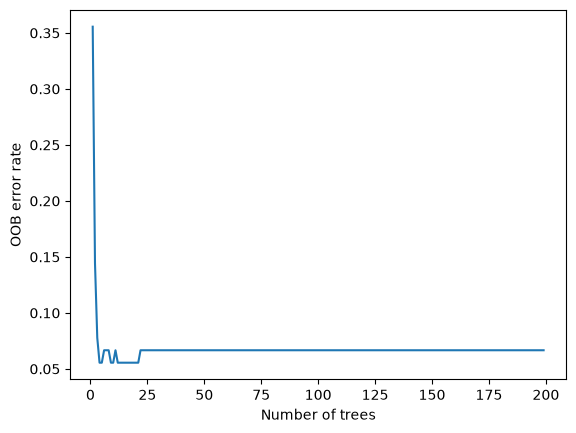

```python
x=range(1,200)
y=oob_errors

plt.plot(x, y)
plt.xlabel("Number of trees")
plt.ylabel("OOB error rate")
plt.show()
```

The x-axis is the "number of trees" and the y-axis is the "OOB error rate". We see that we should use about 50 trees:

```python
random_forest=RandomForestClassifier(criterion="gini",n_estimators=50,bootstrap=True,max_samples=60,max_features=2,oob_score=True,random_state=random_state)
random_forest=random_forest.fit(iris_training,iris_trainingtarget_integers)
```

Comment: The advantage of using the oob accuracy instead of the validation accuracy to determine the best number of trees is that you do not need to keep a validation dataset on the side. If you only use random forests, then you may merge the above training and validation datasets and use oob accuracy (or k-fold cross-validation accuracy) to select the best values for all the hyperparameters. However, in our case, we want to compare the decision tree with the random forest, so we need to use a common separate validation dataset.

Predict the species for the training dataset with the random forest model:

```python
predictions=random_forest.predict(iris_training)
confusion_matrix(iris_trainingtarget_integers,predictions)
```

```
array([[30,  0,  0],
       [ 0, 30,  0],
       [ 0,  0, 30]])
```

This confusion matrix shows that the random forest has made 0 mistake in 90 preditions.

The corresponding training accuracy:

```python
scores=random_forest.score(iris_training,iris_trainingtarget_integers)
print("Training accuracy rate:: %.2f%%"%(scores*100))
print("Training error rate: %.2f%%"%(100-scores*100))
```

```
Training accuracy rate:: 100.00%
Training error rate: 0.00%
```

We obtain 100% accuracy: the random forest has perfecly learned the training data.

Predict the species for the validation dataset:

```python
predictions=random_forest.predict(iris_validation)
confusion_matrix(iris_validationtarget_integers,predictions)
```

```
array([[ 9,  0,  0],
       [ 0, 12,  0],
       [ 0,  0,  9]])
```

This confusion matrix shows that the random forest has made 0 mistake in 30 preditions.

Finally the validation accuracy:

```python
scores=random_forest.score(iris_validation,iris_validationtarget_integers)
print("Validation accuracy rate:: %.2f%%"%(scores*100))
print("Validation error rate: %.2f%%"%(100-scores*100))
```

```
Validation accuracy rate:: 100.00%
Validation error rate: 0.00%
```

Compute and plot the importance (of all the variables):

```python
feature_importance=pd.Series(random_forest.feature_importances_,index=list(iris_test)).sort_values(ascending=False)
feature_importance
```

```
petal_width     0.462074
petal_length    0.386249
sepal_length    0.125392
sepal_width     0.026285
dtype: float64
```

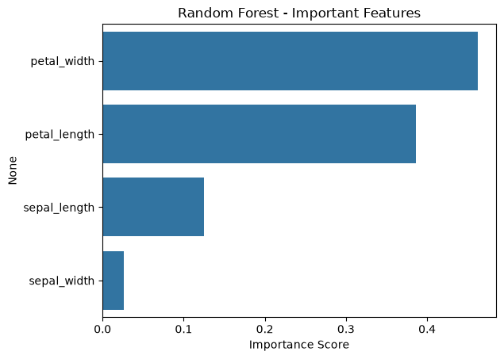

```python
sns.barplot(x=feature_importance,y=feature_importance.index)
plt.xlabel('Importance Score')
plt.title("Random Forest - Important Features")
plt.show()
```

We see that the Petal Length and Petal Width are the two most important predictors. To understand this results, you may want to look back at the previous decision tree and plot of Petal Length versus Petal Width.

Questions: Although we have already found the random forest best model, play around with different hyperparameter values (criterion="entropy", n_estimators (number of trees), bootstrap=False, max_samples, max_features (the number of variables randomly sampled as candidates at each question (or split); default: sqrt(4)=2), and the random_state (initializing the random generator in the random forest)) and see how it affects your model performances.

Once you have found the best model (the one with the highest validation accuracy), you may apply it to the test dataset. In the present situation, the decision tree and random forest gave the same validation accuracy of 1. Let us choose the random forest as our final model. Then

```python
predictions=random_forest.predict(iris_test)
confusion_matrix(iris_testtarget_integers,predictions)
```

```
array([[11,  0,  0],
       [ 0,  7,  1],
       [ 0,  1, 10]])
```

Finally the test accuracy:

```python
scores=random_forest.score(iris_test,iris_testtarget_integers)
print("Test accuracy rate:: %.2f%%"%(scores*100))
print("Test error rate: %.2f%%"%(100-scores*100))
```

```
Test accuracy rate:: 93.33%
Test error rate: 6.67%
```

BONUS 1 - The classification regions and associated decision boundaries: We will use a home made decision plot funtion written by Stephanie W:

```python
def plot_class_map(clf, X, y, title="", **params):

    clf.fit(X, y)

    x_min, x_max = X.iloc[:, 0].min() - .1, X.iloc[:, 0].max() + .1
    y_min, y_max = X.iloc[:, 1].min() - .1, X.iloc[:, 1].max() + .1

    xx, yy = np.meshgrid(np.linspace(x_min, x_max, 100),np.linspace(y_min, y_max, 100))

    Z = clf.predict(np.c_[xx.ravel(), yy.ravel()])
    Z = Z.reshape(xx.shape)

    plt.figure()

    cmap_light = ListedColormap(['#FFAAAA', '#AAFFAA', '#AAAAFF'])
    cmap_bold = ListedColormap(['#FF0000', '#00FF00', '#0000FF'])

    plt.pcolormesh(xx, yy, Z, cmap=cmap_light)

    plt.scatter(X.iloc[:, 0], X.iloc[:, 1], c=y, cmap=cmap_bold)
    plt.xlabel('petal length (cm)')
    plt.ylabel('petal width (cm)')
    plt.axis('tight')
    plt.title(title)
    plt.show()
```

Decision Trees: Let us make the decision tree model with only Petal.Length and Petal.Width:

```python
iris_training=iris_training[["petal_length","petal_width"]]
```

```python
random_state=17
decision_tree=DecisionTreeClassifier(criterion="entropy",min_samples_split=10,min_samples_leaf=5,max_depth=2,random_state=random_state)
```

Let us plot the decision boundaries (with corresponding predicted species domains) based on the training datatset, and add the training data points:

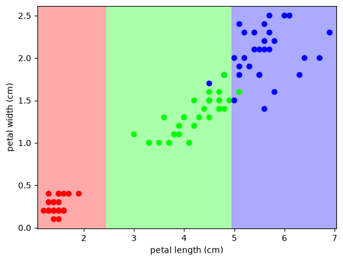

```python
plot_class_map(decision_tree,iris_training,iris_trainingtarget_integers)
```

Random Forests: Let us make the random forest model with only Petal.Length and Petal.Width:

```python
random_forest=RandomForestClassifier(criterion="gini",n_estimators=50,bootstrap=True,max_samples=60,max_features=2,oob_score=True,random_state=random_state)
```

Let us plot the decision boundaries (with corresponding predicted species domains) based on the training datatset, and add the training data points:

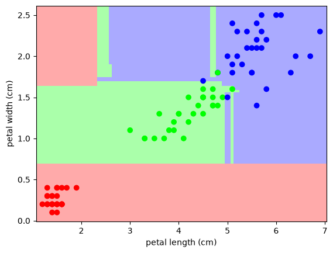

```python
plot_class_map(random_forest,iris_training,iris_trainingtarget_integers)
```

BONUS 2 - Let us find the best hyperparameters by using the Grid Search method

Choose the hyperparameters you want to tune, and the corresponding range of values:

```python
param_grid={
    "criterion":['gini','entropy'],
    "max_depth":range(1,5),
    "min_samples_split":range(1,10),
    "min_samples_leaf":range(1,5)
}
```

Create a tree model to go through our grid search hyperparameter combinations:

```python
decision_tree=DecisionTreeClassifier(random_state=random_state)
```

Iterate through the values of the hyperparameters and fit the corresponding models:

```python
grid=GridSearchCV(decision_tree,param_grid=param_grid,cv=10,verbose=1)
grid.fit(iris_training,iris_trainingtarget_integers)
```

```
Fitting 10 folds for each of 288 candidates, totalling 2880 fits
```

```
GridSearchCV(cv=10, estimator=DecisionTreeClassifier(random_state=17),
             param_grid={'criterion': ['gini', 'entropy'],
                         'max_depth': range(1, 5),
                         'min_samples_leaf': range(1, 5),
                         'min_samples_split': range(1, 10)},
             verbose=1)
```

Sort results by high accuracy, more minsplit and less maxdepth:

```python
df=pd.concat([pd.DataFrame(grid.cv_results_["params"]),pd.DataFrame(grid.cv_results_["mean_test_score"],columns=["Accuracy"])],axis=1)
df.sort_values(by=['Accuracy','min_samples_split'],ascending=False)
```

|  | criterion | max_depth | min_samples_leaf | min_samples_split | Accuracy |
| --- | --- | --- | --- | --- | --- |
| 44 | gini | 2 | 1 | 9 | 0.944444 |
| 53 | gini | 2 | 2 | 9 | 0.944444 |
| 62 | gini | 2 | 3 | 9 | 0.944444 |
| 71 | gini | 2 | 4 | 9 | 0.944444 |
| 80 | gini | 3 | 1 | 9 | 0.944444 |
| ... | ... | ... | ... | ... | ... |
| 243 | entropy | 3 | 4 | 1 | NaN |
| 252 | entropy | 4 | 1 | 1 | NaN |
| 261 | entropy | 4 | 2 | 1 | NaN |
| 270 | entropy | 4 | 3 | 1 | NaN |
| 279 | entropy | 4 | 4 | 1 | NaN |

288 rows × 5 columns

The best tree has hyperameters impurity=gini, max_depth=2 and min_samples_split=9 (actually min_samples_split=2 is also a solution; see below), with several possible values for min_samples_leaf.

Show the best hyperparameters (those that maximize the cross-validation accuracy):

```python
grid.best_params_
```

```
{'criterion': 'gini',
 'max_depth': 2,
 'min_samples_leaf': 1,
 'min_samples_split': 2}
```

```python
grid.best_estimator_
```

```
DecisionTreeClassifier(max_depth=2, random_state=17)
```

```python
grid.best_score_
```

```
np.float64(0.9444444444444444)
```

Show the best tree found by the Grid Search method:

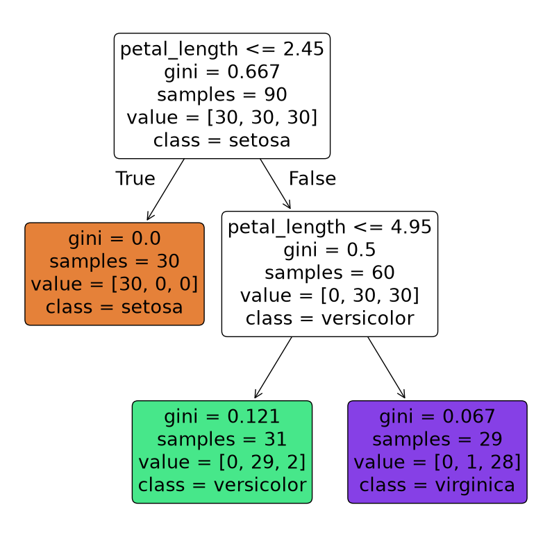

```python
best_tree=grid.best_estimator_
best_tree=best_tree.fit(iris_training,iris_trainingtarget_integers)

plt.figure(figsize=(10,10))
tree.plot_tree(best_tree,feature_names=list(iris_training),class_names=["setosa","versicolor","virginica"],
               filled=True,rounded=True)
plt.show()
```

This tree is different from the one obtained by the pruning method because we use different accuracy metrics: in the pruning method we used the validation accuracy while in the grid search method we used the cross-validation accuracy (with K=10).